# act_report

## Report: act_report

```python
import pandas as pd
import matplotlib.pyplot as plt
%matplotlib inline
df = pd.read_csv('twitter_archive_master.csv')
```

### Insight #1

Looking at the rating_numerator column and the frequency of ratings it can be seen the range of values that come up. Everything from 0 to 1776. Even though the ratings extend up to 1776 the frequency of ratings are skewed to the right when plotted on a bar graph. Every rating after 15 only happens once and the mean of all the ratings is 13. The most commonly used rating, the median in this case, is 12 then follows 10 and 11 as the 2nd and 3rd most common.

To find this data the value_counts() function was used on the rating_numerator column and to find range, mean and median the describe() function was used.

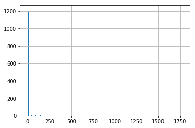

```python
df.rating_numerator.hist(bins=300)
plt.show()
```

### Insight #2

The top 5 dogs most tweeted are the golden retriever, Labrador retriever, Pembroke, Chihuahua, and pug. The number of tweets for each one respectively are 139, 95, 88, 79, and 54. The golden retriever is tweeted more than the others by a rather large margin.

The 5 most tweeted dogs are:

- Golden retriever
- Labrador retriever
- Pembroke
- Chihuahua
- Pug

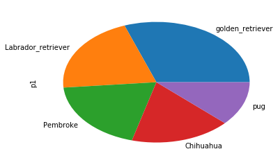

```python
df.p1.value_counts()[:5].plot.pie()
plt.show()
```

### Insight #3

When looking at individual tweets with the most likes only two of the top most tweeted are on the list. The Labrador retriever and chihuahua. Even though the golden retriever has the most posts it does not appear on the list.

The 5 most liked dogs are:

- Labrador retriever
- Chihuahua
- French Bulldog
- Lakeland terrier
- English springer

To find the 5 most liked the value_counts() function was used then then tail() to get the last 5 and since the amount of likes for each id was above 100,000. The type of dog for each id was found by filtering the columns by looking for rows with a ‘favorite_count’ greater than 100,000.